# BME4550_Fall2018_Assignment1

### 5. Will these two graphs look different? Why/why not?

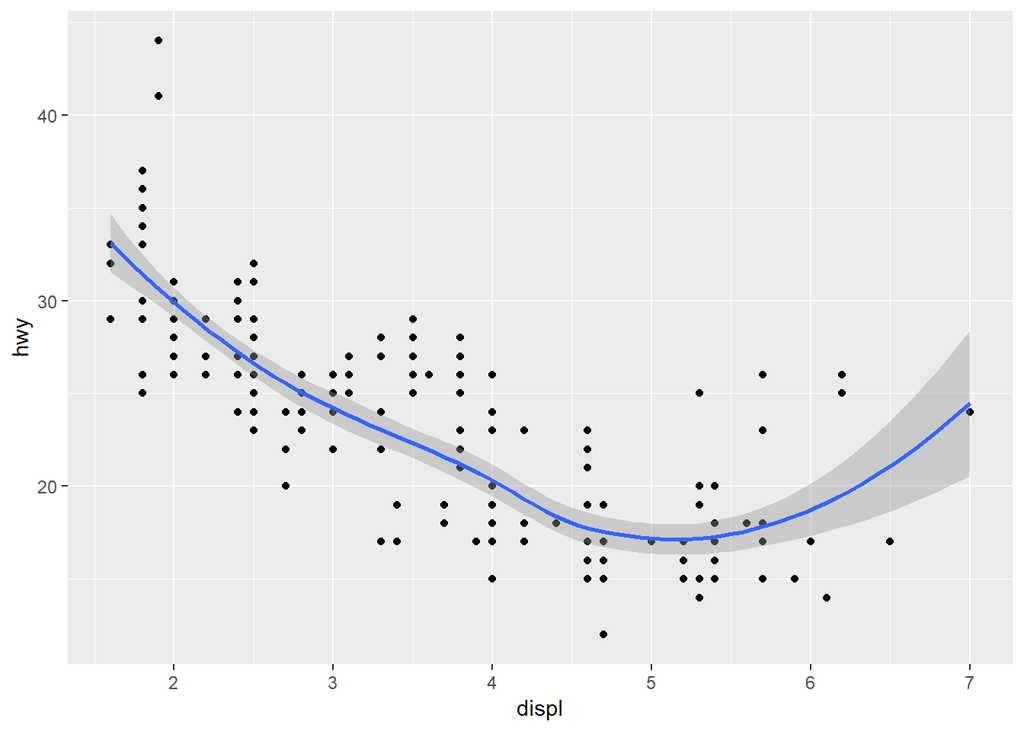

```r
ggplot(data = mpg, mapping = aes(x = displ, y = hwy)) +
  geom_point() +
  geom_smooth()
```

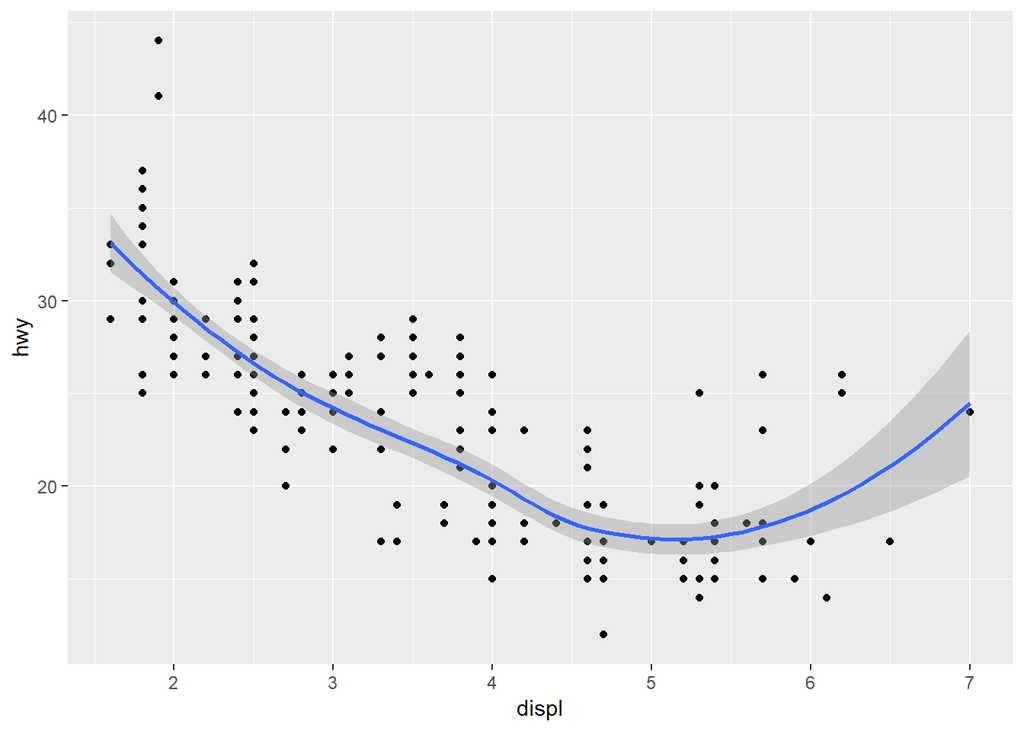

```r
ggplot() +
  geom_point(data = mpg, mapping = aes(x = displ, y = hwy)) +
  geom_smooth(data = mpg, mapping = aes(x = displ, y = hwy))
```

The plots look the exact same because the same arguments are being used for the geoms in both of the two codes. Having the arguments in the ggplot code line makes the arguments global for that ggplot, while having it in the geom makes it local, but if the arguments are the same, then the plot will be the same regardless of where the arguments are.

### 6. Recreate the R code necessary to generate the following graphs

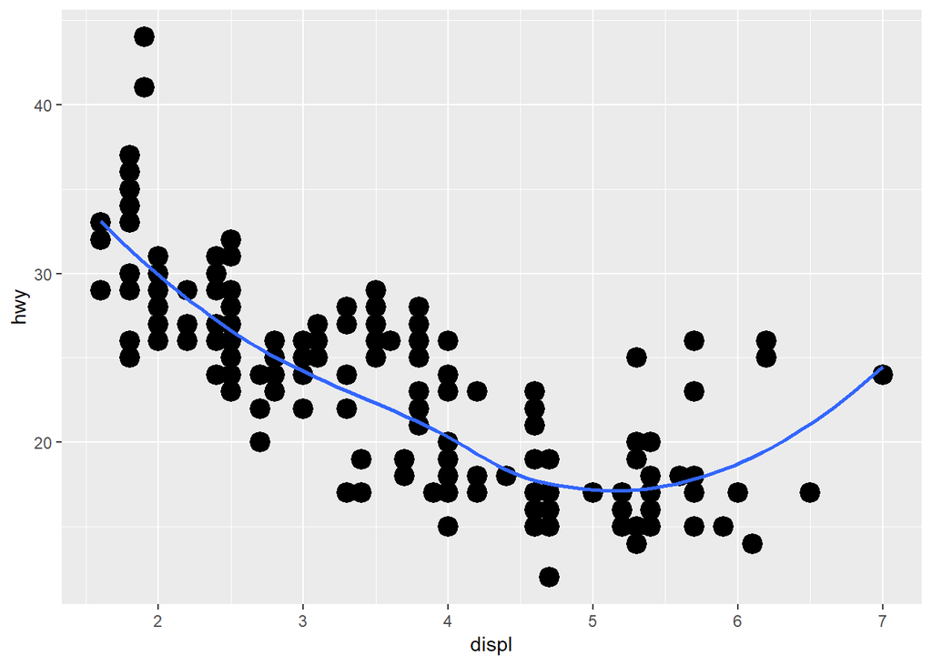

```r
ggplot(data=mpg, mapping = aes(x=displ, y=hwy)) + geom_point(stroke=3) + geom_smooth(se=FALSE)
```

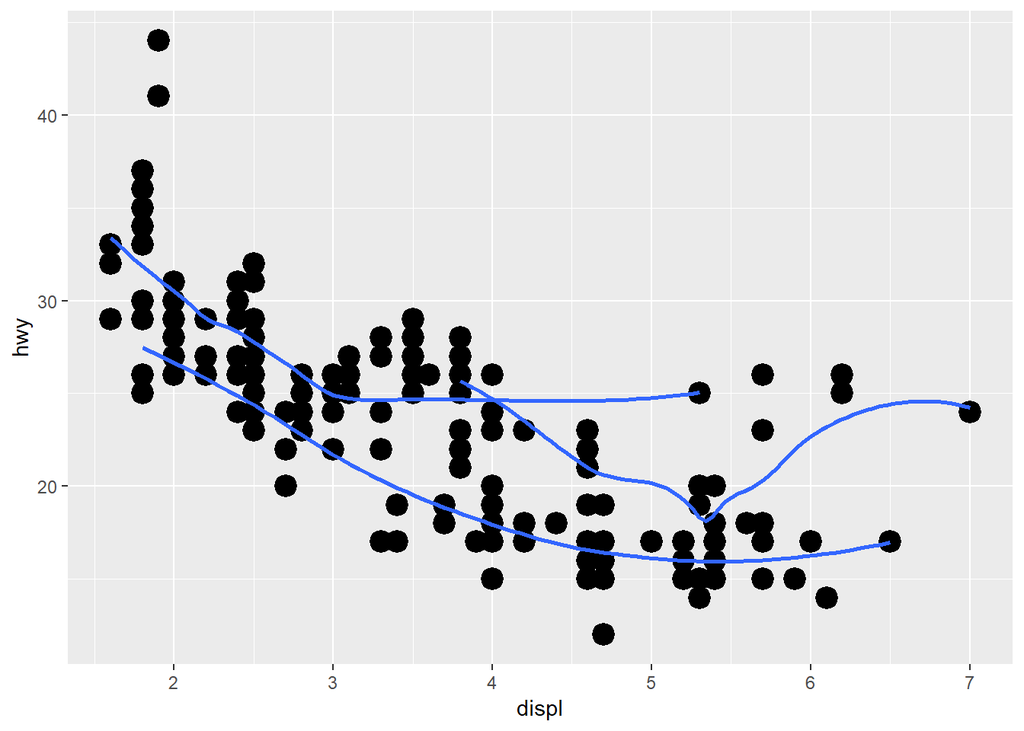

```r
ggplot(data=mpg, mapping = aes(x=displ, y=hwy)) + geom_point(stroke=3) + geom_smooth(se=FALSE, mapping = aes(group= drv))
```

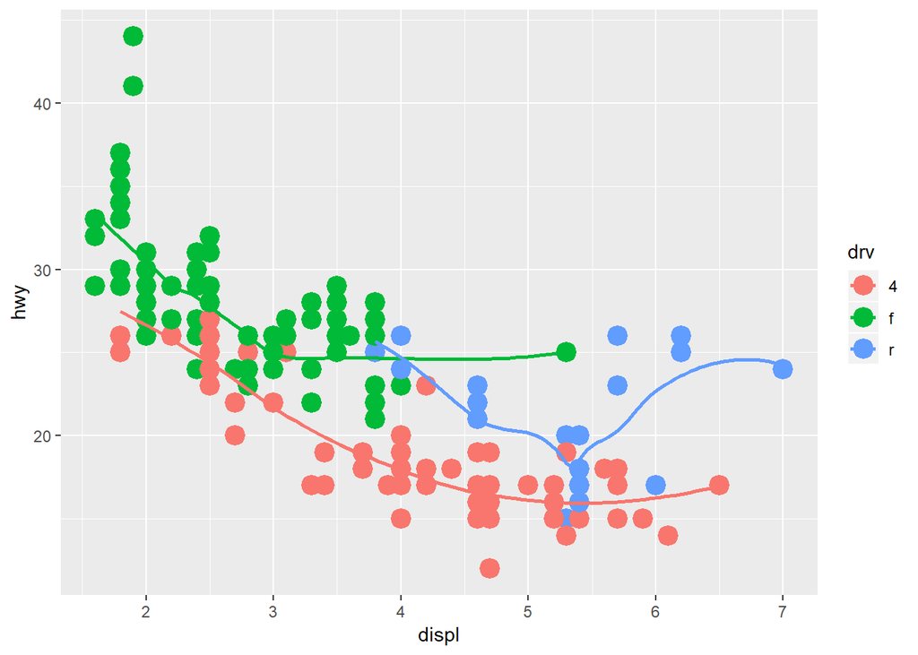

```r
ggplot(data=mpg, mapping = aes(x=displ, y=hwy, color = drv)) + geom_point(stroke=3) + geom_smooth(se=FALSE)
```

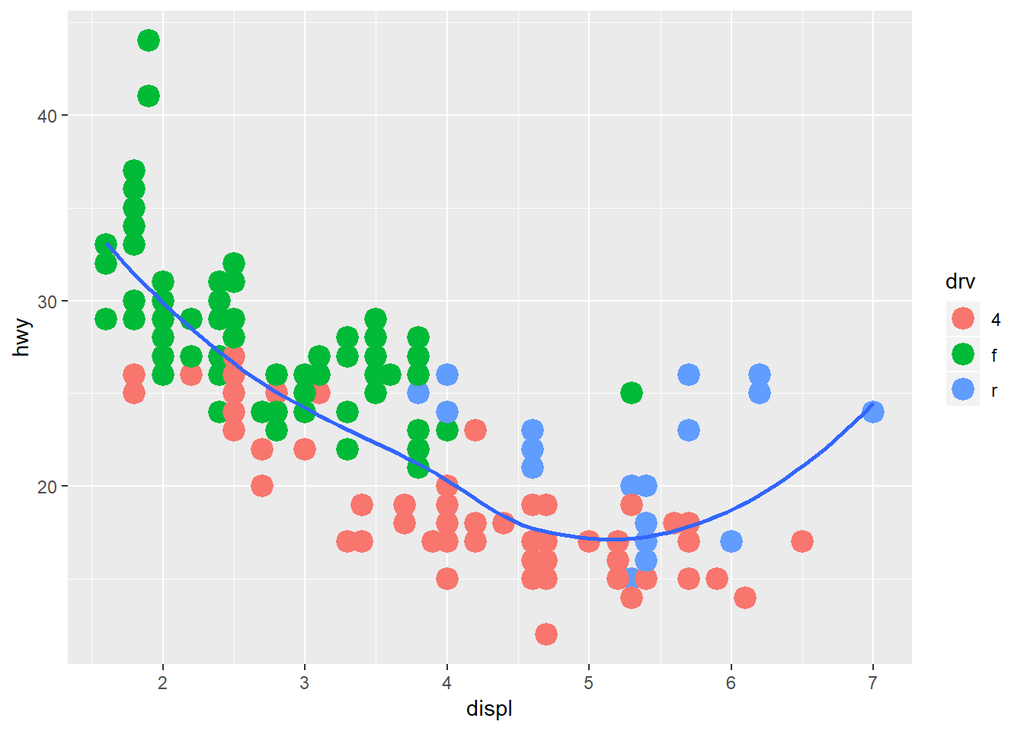

```r
ggplot(data=mpg, mapping=aes(x=displ,y=hwy)) + geom_point(mapping=aes(color=drv),stroke=3) + geom_smooth(se=FALSE)
```

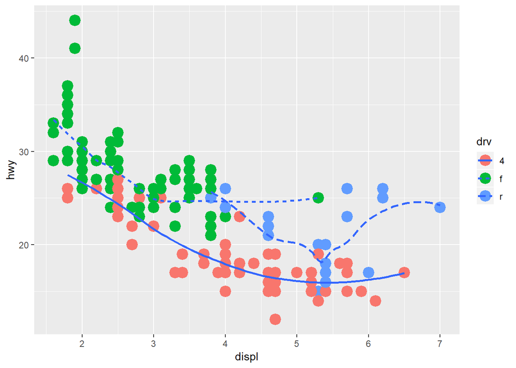

```r
ggplot(data=mpg, mapping=aes(x=displ,y=hwy)) + geom_point(mapping=aes(color=drv),stroke=3) + geom_smooth(mapping =aes(linetype = drv),se=FALSE)
```

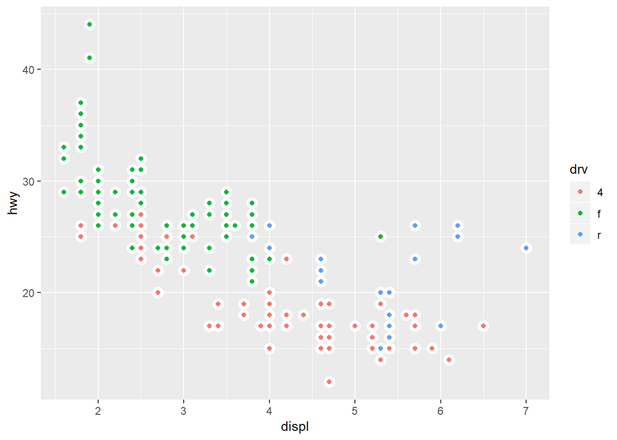

```r
ggplot(data = mpg, mapping = aes(x = displ, y = hwy)) + geom_point(size = 4, colour = "white") + geom_point(aes(colour = drv))
```

## 3.7.1 Exercises

### 1. What is the default geom associated with stat_summary()? How could you rewrite the previous plot to use that geom function instead of the stat function?

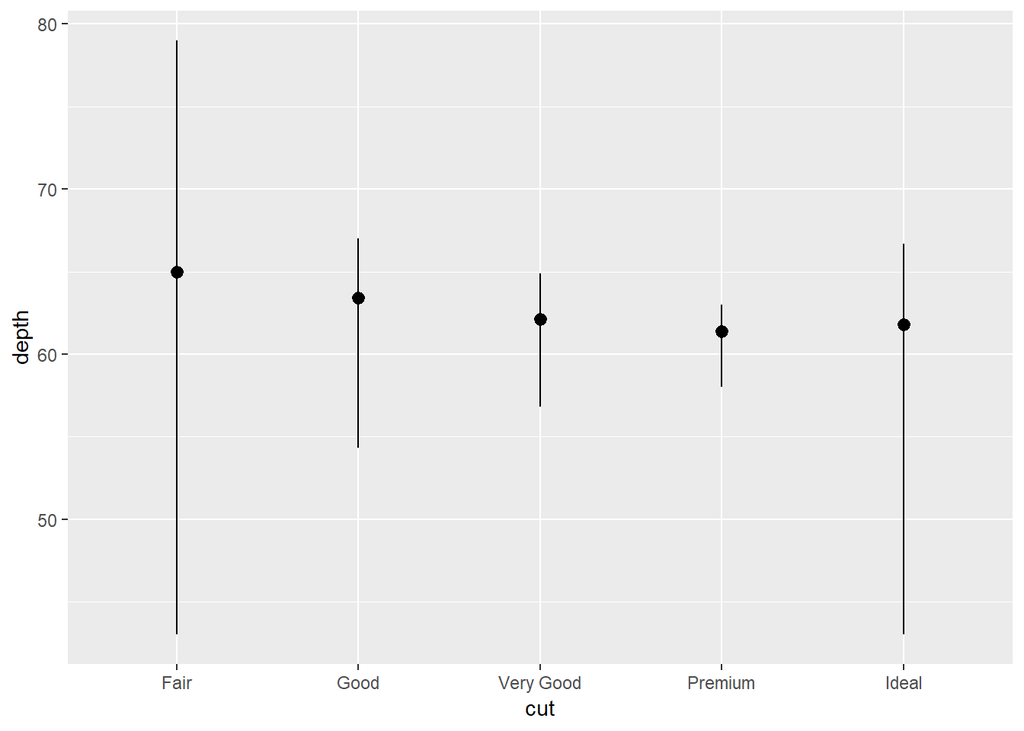

```r
#?stat_summary
ggplot(data = diamonds) +
  stat_summary(mapping = aes(x = cut, y = depth),fun.ymin = min,fun.ymax = max,fun.y = median)
```

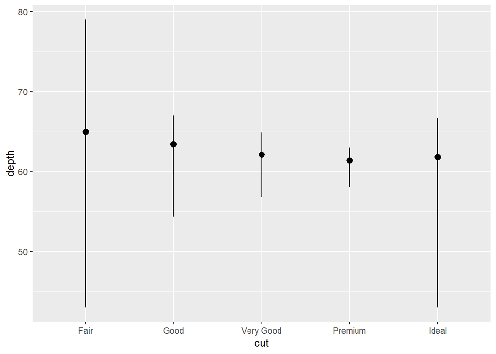

```r
ggplot(data = diamonds) +geom_pointrange(mapping = aes(x = cut, y = depth),stat = "summary",fun.ymin = min,fun.ymax = max,fun.y = median)
```

The default geom associated with stat_summary() is the pointrange geom. However, the stat for geom_pointrange is identity, so you need to specify that summary is the stat you would like to use if you want to use the geom instead of the stat.

### 2. What does geom_col() do? How is it different to geom_bar()?

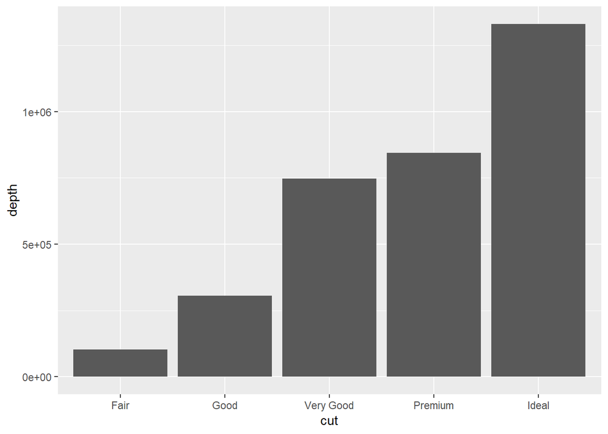

```r
#?geom_col()
#?geom_bar()
ggplot(data=diamonds) + geom_col(mapping=aes(x=cut,y=depth))
```

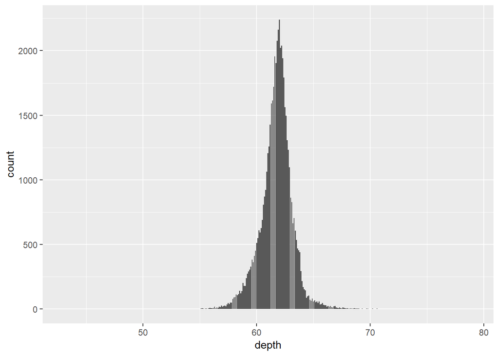

```r
ggplot(data=diamonds) + geom_bar(mapping=aes(x=depth))
```

geom_bar makes the height of all the bars proportional to the number of cases in each group. geom_col makes the height of the bars in the bar graph to represent the value of the y variable. The default stat for col is identity, while for bar the default stat is count. col therefore assumes that the y variable is the count.

### 3. Most geoms and stats come in pairs that are almost always used in concert. Read through the documentation and make a list of all the pairs. What do they have in common?

```r
#??geom
#??stat
```

## stat ##geom

abline abline hline hline bin2d bin2d binhex hex boxplor boxplot contour contour density density density2d density2d quantile quantile smooth smooth vline vline

The pairs rely on each other as inputs into the other one. In general, they are different methods to achieve the same goal.

### 4.What variables does stat_smooth() compute? What parameters control its behaviour?

```r
#?stat_smooth()
ggplot(data=mpg) + stat_smooth(mapping = aes(x=displ,y=hwy))
```

[output not shown]

The computed variables are: y - the predicted value ymin - the lower pointwise confidence interval ymax - the upper pointwise confidence interval se - standard error

Some parameters that can be changed to control the behavior of stat_smooth() are formula, which dictates which formula to use as the smoothing function, method, which chooses the smoothing method to use, n, which controls the number of points at which to evaluate the stat at. There is also span, which controls the amount of smoothing, fullrange which effects the fit of the plot, and level that changes the confidance interval.

### 5 In our proportion bar chart, we need to set group = 1. Why? In other words what is the problem with these two graphs?

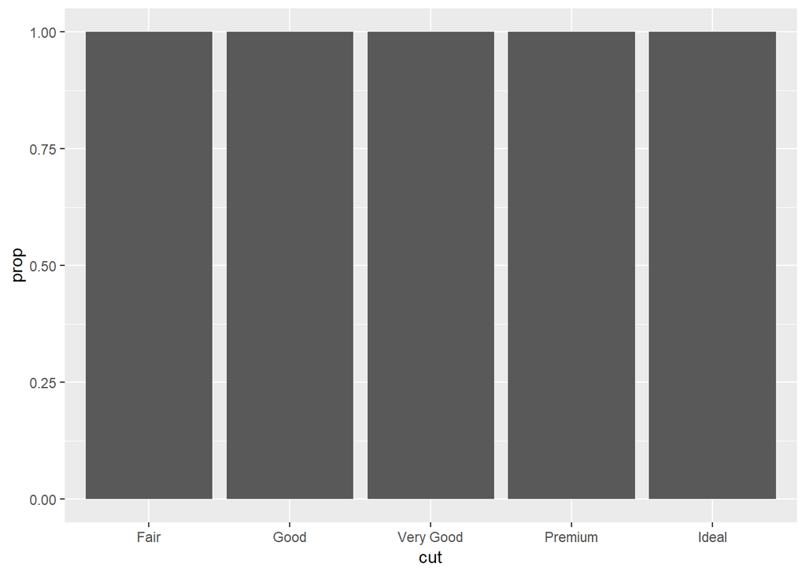

```r
ggplot(data = diamonds) +
  geom_bar(mapping = aes(x = cut, y = ..prop..))
```

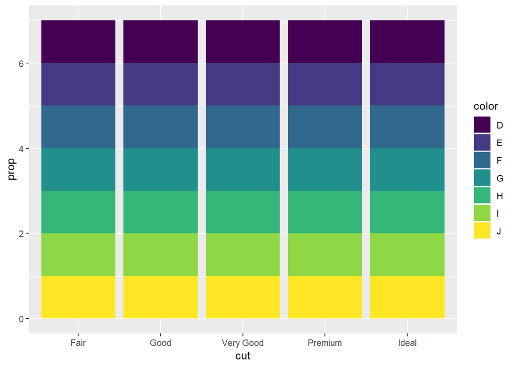

```r
ggplot(data = diamonds) +
  geom_bar(mapping = aes(x = cut, fill = color, y = ..prop..))
```

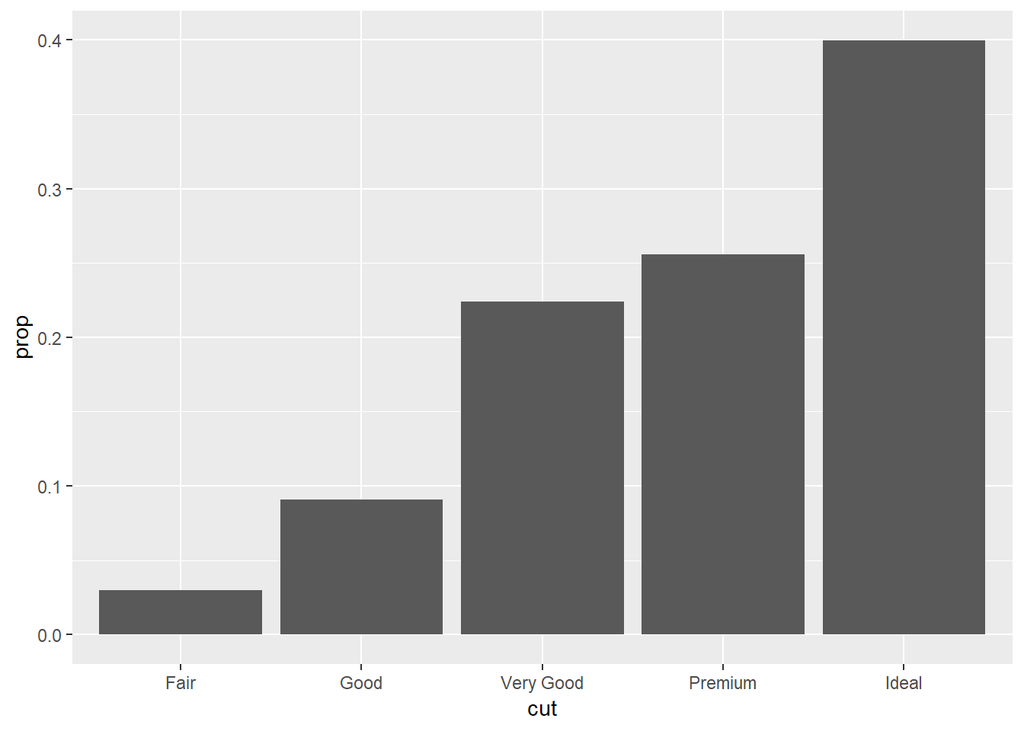

```r
ggplot(data = diamonds) +
  geom_bar(mapping = aes(x = cut, y = ..prop..,group=1))
```

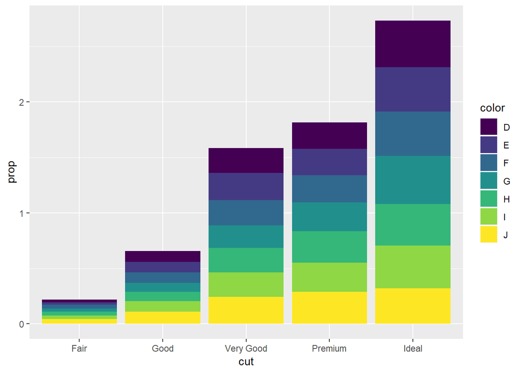

```r
ggplot(data = diamonds) +
  geom_bar(mapping = aes(x = cut, fill = color, y = ..prop.., group=color))
```

The problem with these two graphs is that the height of the bars is scaled to go all the way to the end of the y-axis. The proportion is calculated within the group in this case, which is why they are all full. When you set group to 1, the graphs are no longer scaled all the way up and the height now represents the correct proportion of 1 they represent.

## 3.8.1 Exercises

### 1. What is the problem with this plot? How could you improve it?

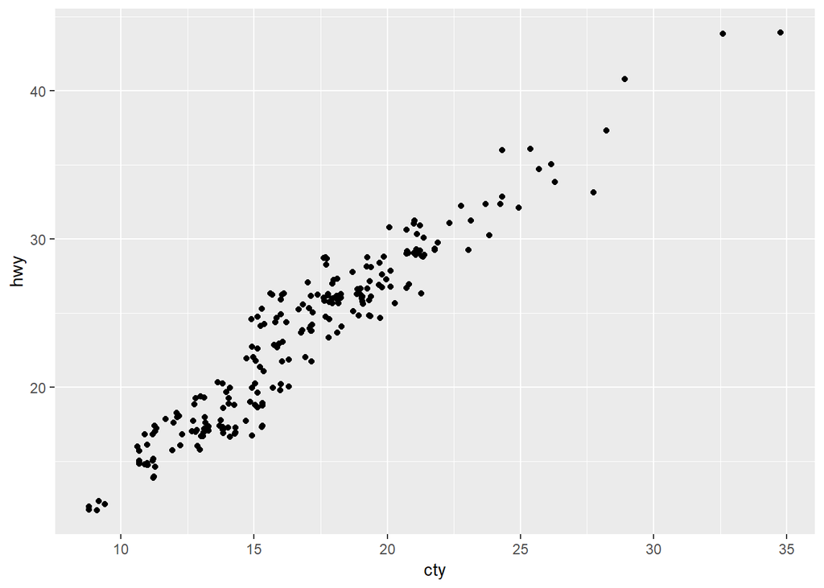

```r
ggplot(data = mpg, mapping = aes(x = cty, y = hwy)) +
  geom_point(position="jitter")
```

The issue is that cty and hwy are both continuous variables and so they get rounded when they get plotted and if some of the vaues get rounded to the same numbers, they will only be plotted once. By setting the position to jitter, it slightly moves all the data points randomly, therefore showing all the points now.

### 2. What parameters to geom_jitter() control the amount of jittering?

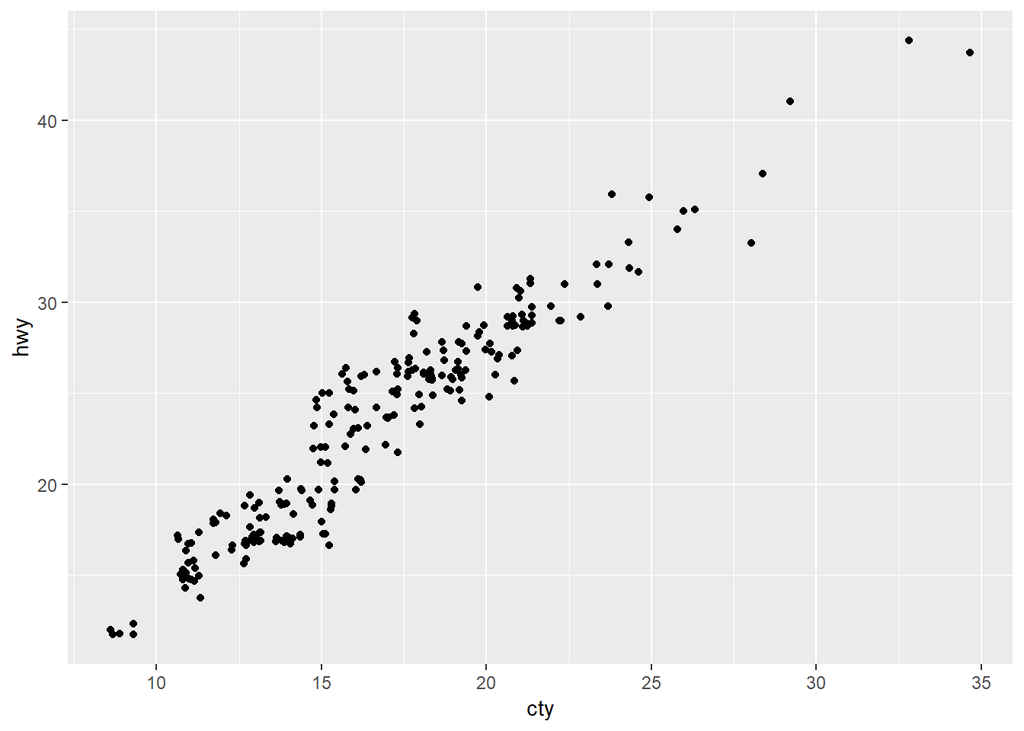

```r
#?geom_jitter()
ggplot(data = mpg, mapping = aes(x = cty, y = hwy)) +
  geom_jitter()
```

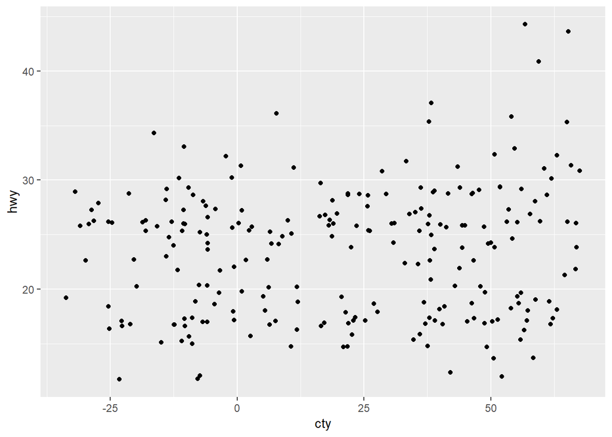

```r
ggplot(data = mpg, mapping = aes(x = cty, y = hwy)) +
  geom_jitter(width = 50)
```

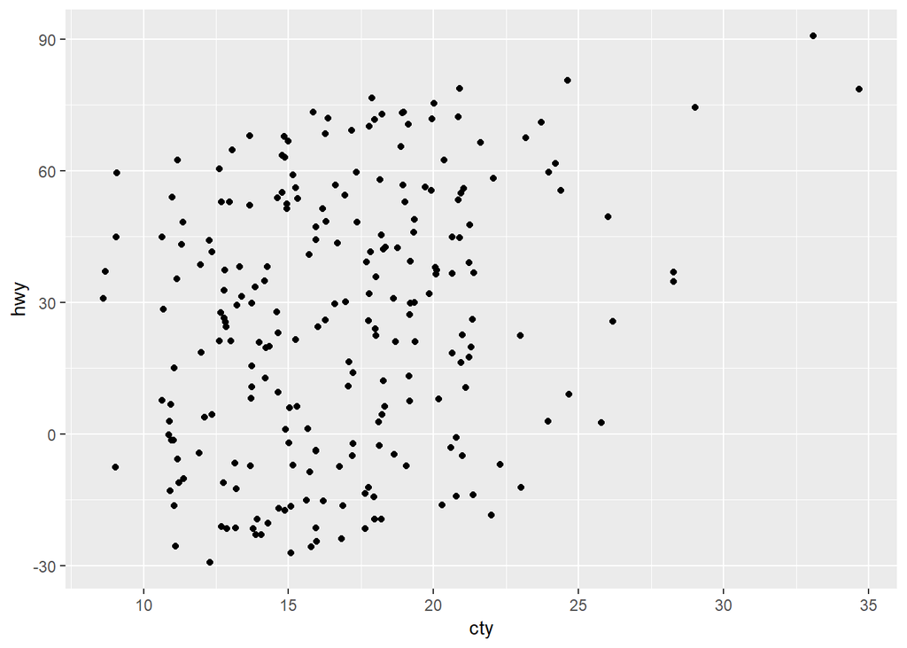

```r
ggplot(data = mpg, mapping = aes(x = cty, y = hwy)) +
  geom_jitter(height = 50)
```

width changes the amount of horizontal jitter. height also changes the amount of vertical jitter.

### 3. Compare and contrast geom_jitter() with geom_count()

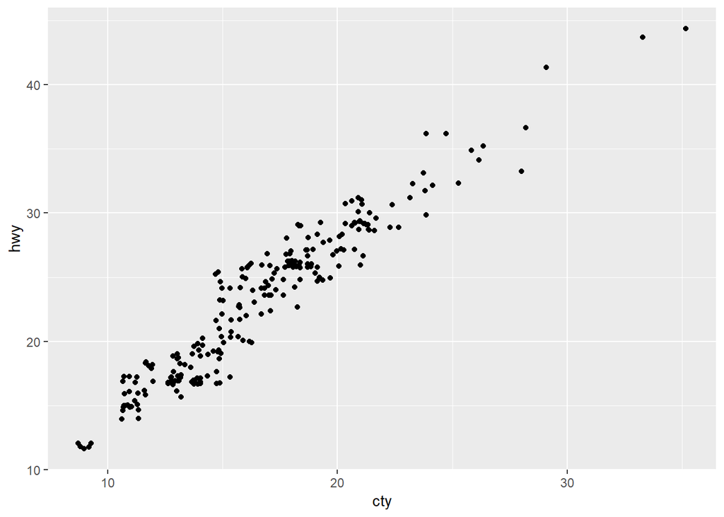

```r
#?geom_jitter()
#?geom_count()
ggplot(data = mpg, mapping = aes(x = cty, y = hwy)) +
  geom_jitter()
```

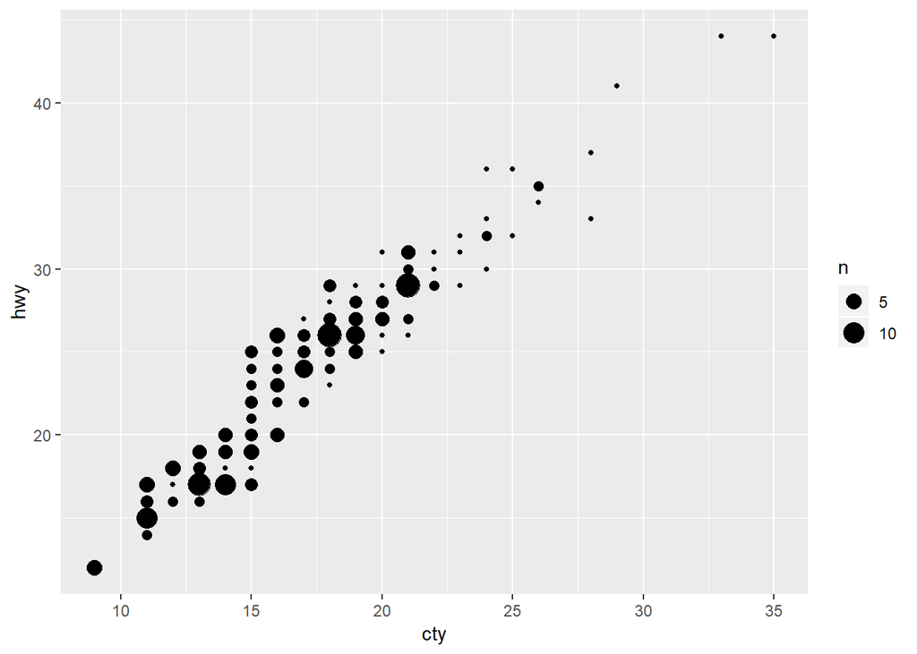

```r
ggplot(data = mpg, mapping = aes(x = cty, y = hwy)) +
  geom_count()
```

geom_jitter() creates a scatterplot that adds a random amount of variation to the lcoation of each point, used to help avoid overplotting. geom_count() also creates a scatterplot but counts the number of observations at each location and adjusts the area of the point based on the count. Both are helpful to counteract the effects of overplotting.

### 4. What’s the default position adjustment for geom_boxplot()? Create a visualisation of the mpg dataset that demonstrates it.

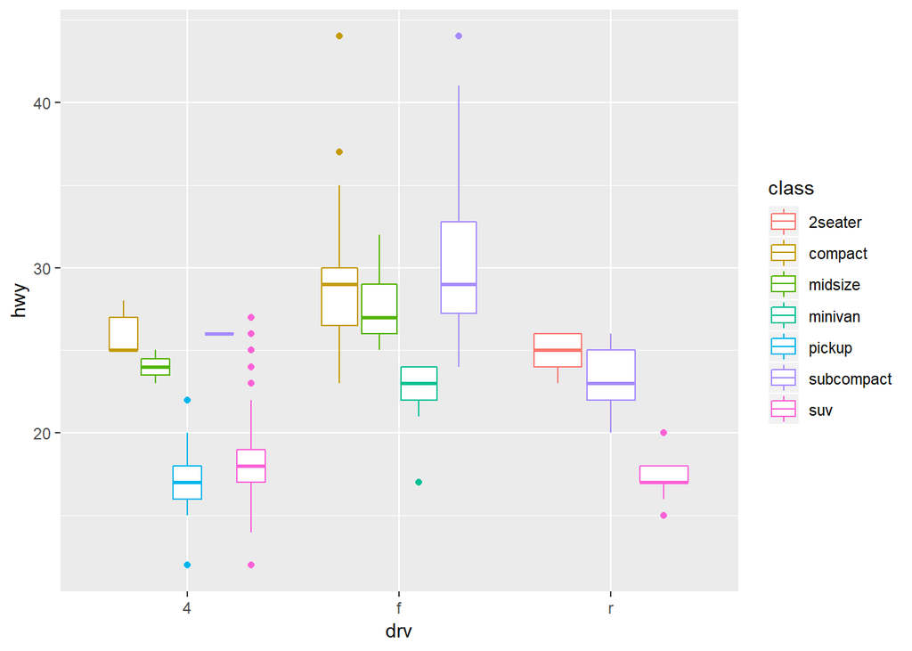

```r
#?geom_boxplot()
ggplot(data = mpg, aes(x = drv, y = hwy, colour = class)) +
  geom_boxplot()
```

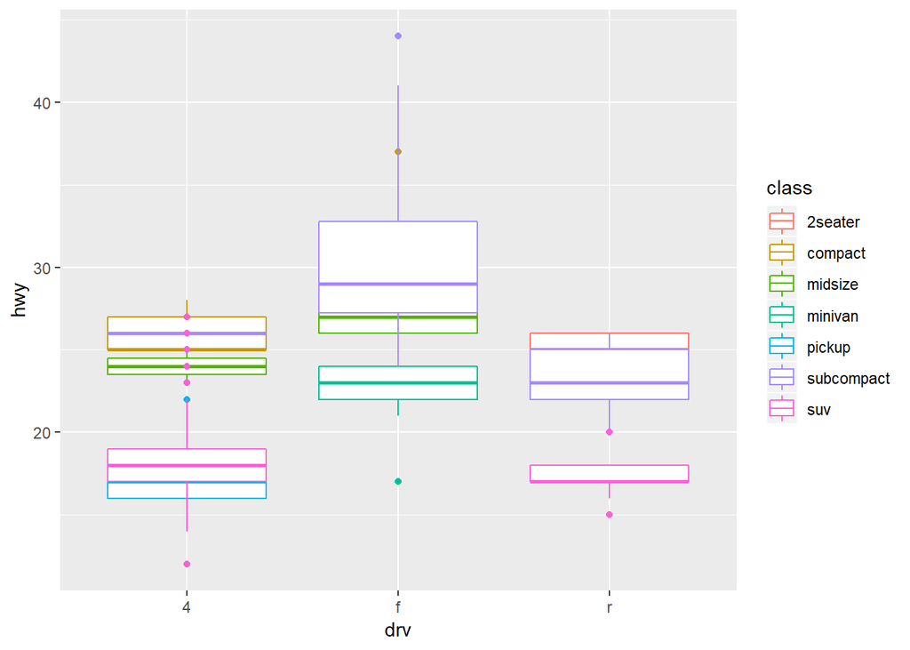

```r
ggplot(data = mpg, aes(x = drv, y = hwy, colour = class)) +
  geom_boxplot(position="identity")
```

The default position adjustment for geom_boxplot is “dodge2”. This makes it so that there is a good amount of space separating the different boxplots, allowing for easier visualization of the data. If the position is changed to identity, a lot of them overlap because they are just placed on the graph where their values say they should.

## 3.9.1 Exercises

### 1. Turn a stacked bar chart into a pie chart using coord_polar

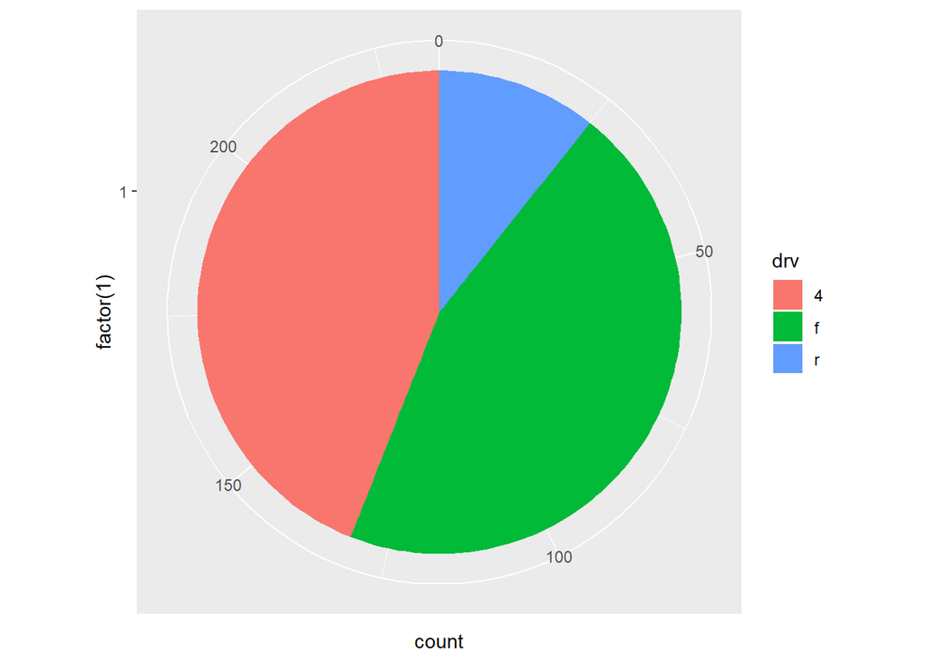

```r
ggplot(mpg, aes(x = factor(1), fill = drv)) + geom_bar(width = 1) + coord_polar(theta = "y")
```

### 2. What does labs() do? Read the documentation.

```r
#?labs()
```

labs() allows you to label your plots. You can se it to add labels for the axes, titles, subtitles and captions.

### 3. What’s the difference between coord_quickmap() and coord_map()?

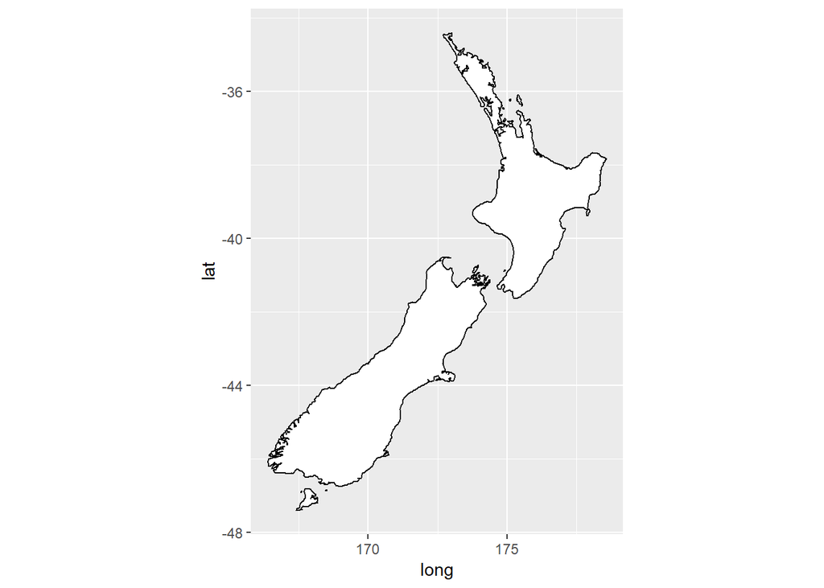

```r
#?coord_quickmap()
#?coord_map()
library(maps)
library(mapproj)
nz <- map_data("nz")
ggplot(nz, aes(long, lat, group = group)) +
  geom_polygon(fill = "white", colour = "black") +
  coord_quickmap()
```

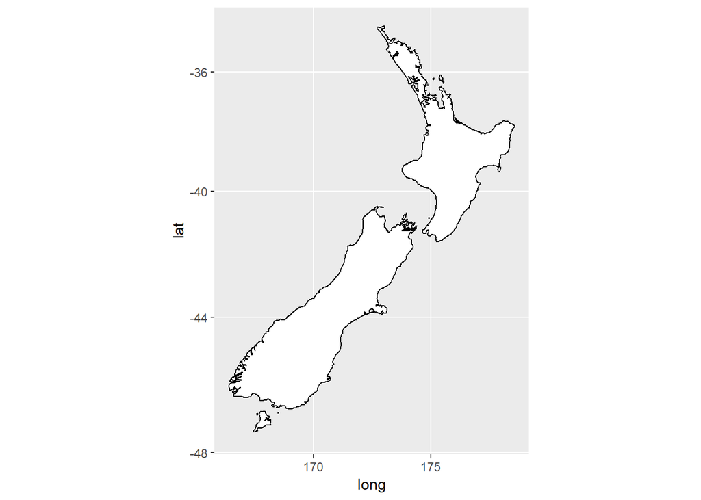

```r
ggplot(nz, aes(long, lat, group = group)) +
  geom_polygon(fill = "white", colour = "black") +
  coord_map()
```

coord_map projects a portion of the earth, which is spherical onto a flat 2D plane. It uses mapproj package and does not preserve straight lines, making it computationally intensive. coord_quickmap on the other land preserves straight line and is a quick approximation. Documentation says it works the best for small areas close to the equator.

### 4. What does the plot below tell you about the relationship between city and highway mpg? Why is coord_fixed() important? What does geom_abline() do?

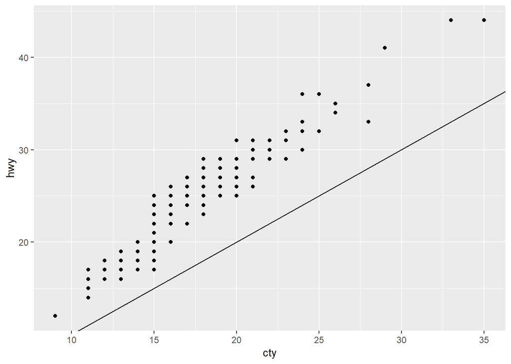

```r
ggplot(data = mpg, mapping = aes(x = cty, y = hwy)) +
  geom_point() +
  geom_abline()
```

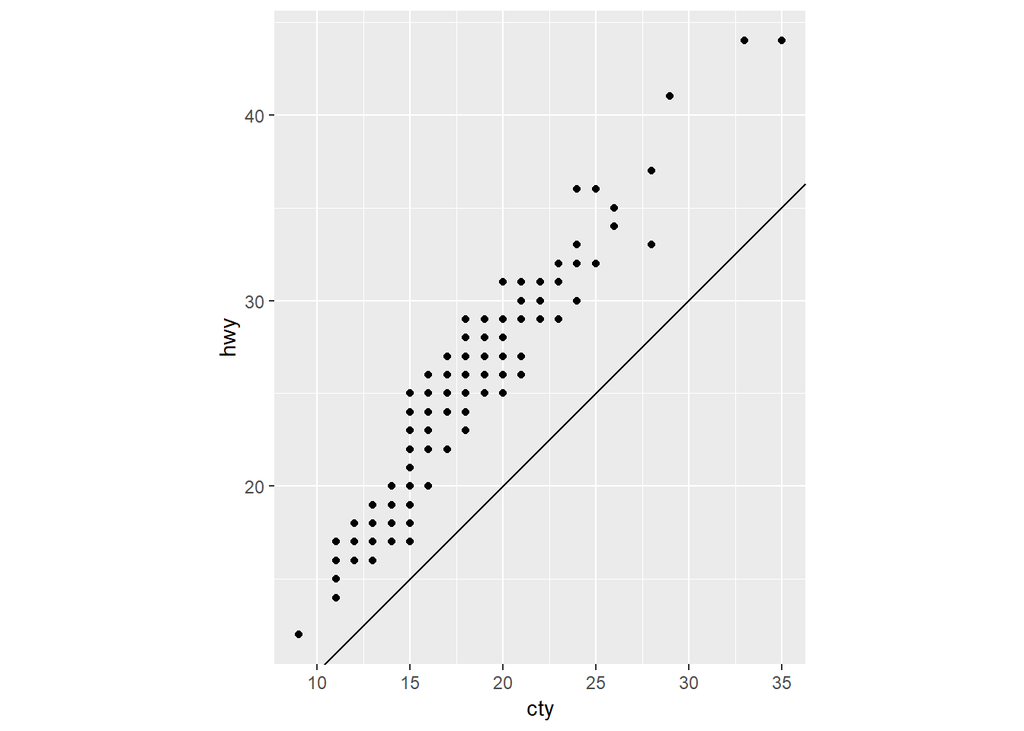

```r
ggplot(data = mpg, mapping = aes(x = cty, y = hwy)) +
  geom_point() +
  geom_abline() +
  coord_fixed()
```

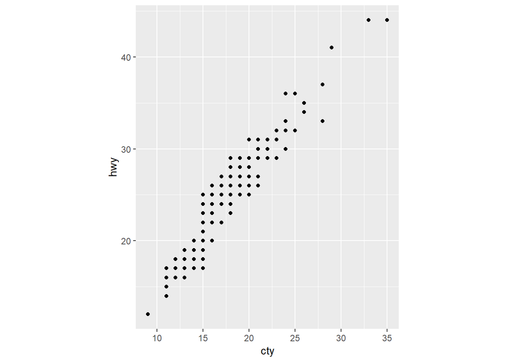

```r
ggplot(data = mpg, mapping = aes(x = cty, y = hwy)) +
  geom_point() +
  coord_fixed()
```

```r
#?coord_fixed
#?geom_abline
```

The plot tells you that there is a positive relationship between city and highway mpg. In general, cars with higher city mpg will have a higher highway mpg than those with a lower city mpg. coord_fixed is important because it sets a fixed ratio between the physical reprsentation of data units on the axes. The ratio is the ratio of y units to x units. geom_abline creates a reference line that you can choose the slope and intercept of. When used with coord_fixed, which creates a ratio of 1(1mpg = 1mpg), the abline is at a 45 degree angle or slope of 1.